# GLM, glmtools, GLMr Tutorial

09 March, 2016

## Introduction

Goals for today's workshop

- **GLM**: basic understanding of lake model
- **GLMr**: run GLM from R, keep up-to-date version of **GLM**
- **glmtools**: reproducible model results handling and visualizations

## Lake modeling overview

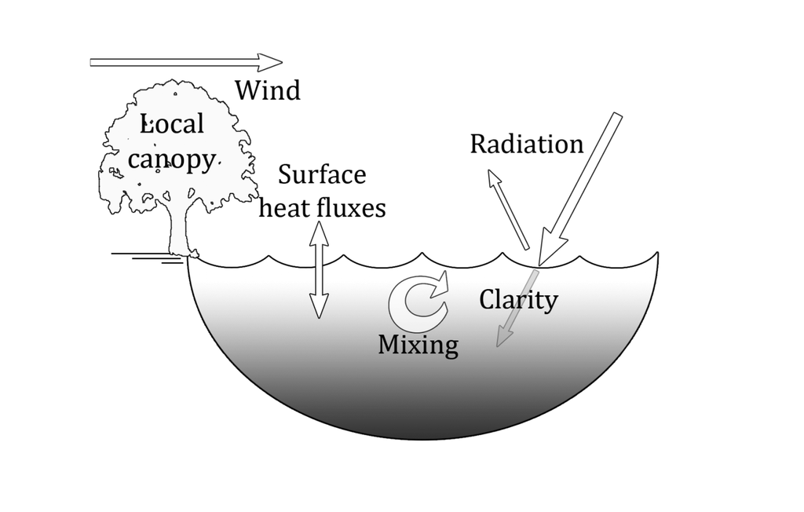

## Lake modeling overview

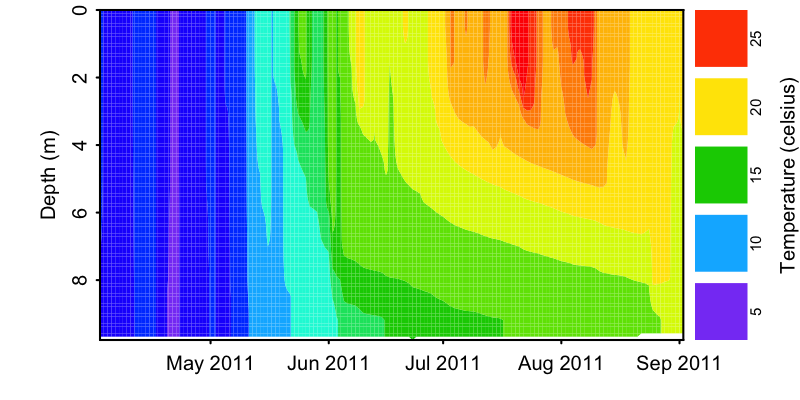

## GLM

GLM "General Lake Model"

Authors: Matthew R Hipsey, Louise C Bruce, David P Hamilton

Location: [GLM website](http://aed.see.uwa.edu.au/research/models/GLM/)

The GLM model has been developed as an initiative of the Global Lake Ecological Observatory Network (GLEON) and in collaboration with the Aquatic Ecosystem Modelling Network (AEMON) that started in 2010. The model was first introduced in Leipzig at the 2nd Lake Ecosystem Modelling Symposium in 2012, and has since developed rapidly with application to numerous lakes within the GLEON network and beyond.

Source code available at http://github.com/GLEON/GLM-source

## GLM overview

[figure not shown]

## GLM overview

[figure not shown]

## GLM overview

[figure not shown]

## GLM overview

[figure not shown]

## GLMr

GLMr R package

Maintainer: Luke A Winslow

Authors: Luke A Winslow, Jordan S Read

Location: https://github.com/GLEON/GLMr

GLMr holds the current version of the "General Lake Model",  
and can run the model on all platforms (windows, mac, linux) directly from R

## Installation

`glmtools` is available on the GRAN repository.

```r
install.packages(c("GLMr", "glmtools"), repos = c("http://owi.usgs.gov/R",
    getOption("repos")))
```

More information can be found [here](http://owi.usgs.gov/R/gran.html).

## GLMr

GLMr Code in R:

```r
library(GLMr)

glm_version()

nml_template_path()
```

Explanation

- load the GLMr package in R
- get the current version of GLM
- find the included example glm.nml

## GLMr

GLMr Code in R:

- run the GLM model on your computer

```r
run_glm(sim_folder)
```

```
       ------------------------------------------------
       |  General Lake Model (GLM)   Version 2.1.8    |
       ------------------------------------------------
nDays 0 timestep 3600.000000
Maximum lake depth is 9.753600
Wall clock start time :  Mon Mar 07 16:28:55 2016
Simulation begins...
Wall clock finish time : Mon Mar 07 16:28:55 2016
Wall clock runtime 0 seconds : 00:00:00 [hh:mm:ss]

------------------------------------------------
              Run Complete
Reading config from glm2.nml
No WQ config
No diffuser data, setting default values
simulation complete.
```

## GLMr

```r
citation("GLMr")
```

```
##
##
##   Hipsey, M.R., Bruce, L.C., Hamilton, D.P., 2013.
##   GLM General Lake Model. Model Overview and User
##   Information. The University of Western Australia
##   Technical Manual, Perth, Australia.
##
## A BibTeX entry for LaTeX users is
##
##   @Article{,
##     author = {Matthew R. Hipsey and Louise C. Bruce and David P. Hamilton},
##     title = {GLM General Lake Model. Model Overview and User Information},
##     journal = {The University of Western Australia Technical Manual, Perth, Australia},
##     year = {2013},
##   }
##
## As GLM changes, this package will change with it, and
## the citation may change too. Find GLM version with
## 'glm_version()'.
```

Explanation

- Get the current citation for GLM

## glmtools

glmtools R package

Maintainer: Jordan S Read

Authors: Jordan S Read, Luke A Winslow

Location: https://github.com/USGS-R/glmtools

glmtools includes basic functions for calculating physical derivatives and thermal properties of model output, and plotting functionality. glmtools uses GLMr to run GLM

## glmtools section 1

**Goals**  
- *understand model inputs*  
- *run model*  
- *visualize results*

## glmtools model inputs: parameters

- **Excercise:** create and find your example folder

I am going to use a temporary directory, but you can pick any empty directory you want

```r
library(glmtools)
```

```r
tmp_run_dir = file.path(tempdir(), "glm_egs")
tmp_run_dir
```

```
## [1] "/var/folders/y_/1qp06xmj2ws0t8kv54q8wxgh0000gp/T//Rtmp2Q7O7H/glm_egs"
```

```r
dir.create(tmp_run_dir)
```

- Navigate to that directory in your file finder

## glmtools run example simulation

Now run the `run_example_sim` command and see the files created

```r
run_example_sim(tmp_run_dir, verbose = FALSE)
```

```
## [1] "/var/folders/y_/1qp06xmj2ws0t8kv54q8wxgh0000gp/T//Rtmp2Q7O7H/glm_egs"
```

You should have a directory that looks like this

[figure not shown]

## glmtools model inputs: parameters

- load glmtools
- specify location of glm.nml file
- read glm.nml file into R
- print (view) the contents of the nml file

```r
library(glmtools)
nml_file <- file.path(tmp_run_dir, "glm2.nml")
nml <- read_nml(nml_file)
nml
```

```
## &glm_setup
##    sim_name = 'GLMSimulation'
##    max_layers = 500
##    min_layer_vol = 0.025
##    min_layer_thick = 0.5
##    max_layer_thick = 1.5
##    Kw = 0.55
##    coef_mix_conv = 0.125
##    coef_wind_stir = 0.23
##    coef_mix_shear = 0.2
##    coef_mix_turb = 0.51
##    coef_mix_KH = 0.3
##    coef_mix_hyp = 0.5
## /
## &morphometry
##    lake_name = 'Anvil'
##    latitude = 32
##    longitude = 35
##    bsn_len = 21000
##    bsn_wid = 13000
##    bsn_vals = 15
##    H = 510.5363, 511.23299, 511.92967, 512.62636, 513.32304, 514.01973, 514.71641, 515.4131, 516.10979, 516.80647, 517.50316, 518.19984, 518.89653, 519.59321, 520.2899
##    A = 0, 108964, 217929, 326893, 435858, 544822.5, 653787, 762751, 871716, 980680, 1089645, 1198609, 1307574, 1416538, 1525503
## /
## &time
##    timefmt = 2
##    start = '2011-04-01 00:00:00'
##    stop = '2011-09-02 00:00:00'
##    dt = 3600
##    timezone = 7
## /
## &output
##    out_dir = '.'
##    out_fn = 'output'
##    nsave = 24
##    csv_lake_fname = 'lake'
##    csv_point_nlevs = 0
##    csv_point_fname = 'WQ_'
##    csv_point_at = 17
##    csv_point_nvars = 2
```

[output cut: 65 more lines]

```
##    bsn_len_outl = 799
##    bsn_wid_outl = 399
##    outflow_fl = 'outflow.csv'
##    outflow_factor = 0.8
## /
## &snowice
##    snow_albedo_factor = 1
##    snow_rho_max = 300
##    snow_rho_min = 50
## /
## &sed_heat
##    sed_temp_mean = 9.7
##    sed_temp_amplitude = 2.7
##    sed_temp_peak_doy = 242.5
## /
```

## glmtools model inputs: parameters

- get values for specific parameters

```r
get_nml_value(nml, "sim_name")
```

```
## [1] "GLMSimulation"
```

```r
get_nml_value(nml, "Kw")
```

```
## [1] 0.55
```

## glmtools model inputs: meteorological drivers

- plot meteorological drivers for simulation

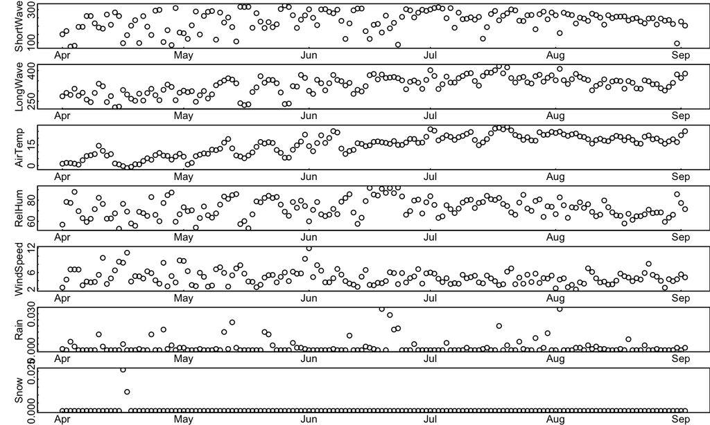

```r
plot_meteo(nml_file)
```

## glmtools run model

- set simulation folder for GLM
- run GLM model

```r
basename(tmp_run_dir)
```

```
## [1] "glm_egs"
```

```r
run_glm(tmp_run_dir)
```

```
## [1] 0
```

## glmtools visualize results

- set output results file
- plot water temperatures

```r
nc_file <- file.path(tmp_run_dir, "output.nc")
```

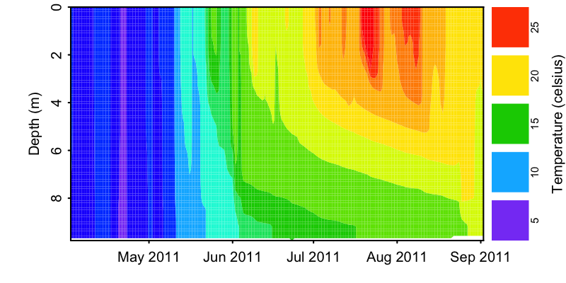

```r
plot_temp(file = nc_file, fig_path = "../images/temperature.png")
```

## glmtools section 2

**Goals**  
- *validate/evaluate model outputs*  
- *modify model parameters*  
- *run simulation with modified parameters*

## glmtools: modify model parameters

- change parameter value
- view nml with change

```r
nml <- set_nml(nml, arg_name = "Kw", arg_val = 1.05)
```

```r
print(nml)
```

```
## &glm_setup
##    sim_name = 'GLMSimulation'
##    max_layers = 500
##    min_layer_vol = 0.025
##    min_layer_thick = 0.5
##    max_layer_thick = 1.5
##    Kw = 1.05
##    coef_mix_conv = 0.125
##    coef_wind_stir = 0.23
##    coef_mix_shear = 0.2
##    coef_mix_turb = 0.51
##    coef_mix_KH = 0.3
##    coef_mix_hyp = 0.5
## /
## &morphometry
##    lake_name = 'Anvil'
##    latitude = 32
##    longitude = 35
##    bsn_len = 21000
##    bsn_wid = 13000
##    bsn_vals = 15
##    H = 510.5363, 511.23299, 511.92967, 512.62636, 513.32304, 514.01973, 514.71641, 515.4131, 516.10979, 516.80647, 517.50316, 518.19984, 518.89653, 519.59321, 520.2899
##    A = 0, 108964, 217929, 326893, 435858, 544822.5, 653787, 762751, 871716, 980680, 1089645, 1198609, 1307574, 1416538, 1525503
## /
## &time
##    timefmt = 2
##    start = '2011-04-01 00:00:00'
##    stop = '2011-09-02 00:00:00'
##    dt = 3600
##    timezone = 7
## /
## &output
##    out_dir = '.'
##    out_fn = 'output'
##    nsave = 24
##    csv_lake_fname = 'lake'
##    csv_point_nlevs = 0
##    csv_point_fname = 'WQ_'
##    csv_point_at = 17
##    csv_point_nvars = 2
```

[output cut: 65 more lines]

```
##    bsn_len_outl = 799
##    bsn_wid_outl = 399
##    outflow_fl = 'outflow.csv'
##    outflow_factor = 0.8
## /
## &snowice
##    snow_albedo_factor = 1
##    snow_rho_max = 300
##    snow_rho_min = 50
## /
## &sed_heat
##    sed_temp_mean = 9.7
##    sed_temp_amplitude = 2.7
##    sed_temp_peak_doy = 242.5
## /
```

## glmtools: re-run simulation

- write changed glm.nml to file
- run GLM model

```r
write_nml(glm_nml = nml, file = nml_file)

run_glm(tmp_run_dir)
```

```
## [1] 0
```

## glmtools: visualize result

- double check nc_file path
- quickly visualize new temps

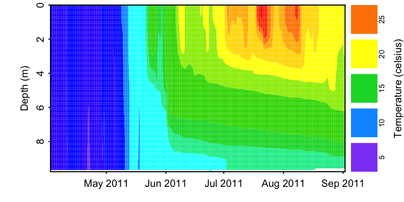

```r
nc_file <- file.path(tmp_run_dir, "output.nc")
plot_temp(file = nc_file, fig_path = "../images/temperature2.png")
```

## glmtools: visualize result

- find simulation variables

```r
sim_vars(file = nc_file)
```

```
##         name    unit         longname
## 1       evap     m/s      evaporation
## 2  extc_coef unknown        extc_coef
## 3       hice                     hice
## 4      hsnow                    hsnow
## 5      hwice                    hwice
## 6        I_0                      I_0
## 7         NS                       NS
## 8     precip     m/s    precipitation
## 9        rad unknown  solar radiation
## 10       rho unknown          density
## 11      salt    g/kg         salinity
## 12      temp celsius      temperature
## 13     Tot_V      m3      lake volume
## 14    u_mean     m/s    mean velocity
## 15     u_orb     m/s orbital velocity
## 16         V      m3     layer volume
## 17      wind     m/s             wind
```

## glmtools: visualize result

- quickly visualize other variables

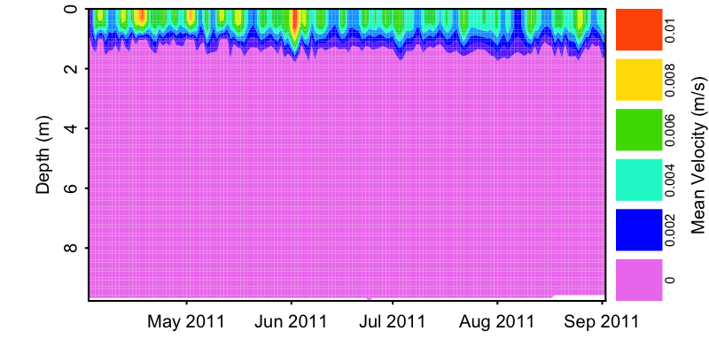

```r
plot_var(file = nc_file, var_name = "u_mean", fig_path = "../images/velocity.png")
```

## glmtools: visualize result

- quickly compare to field data

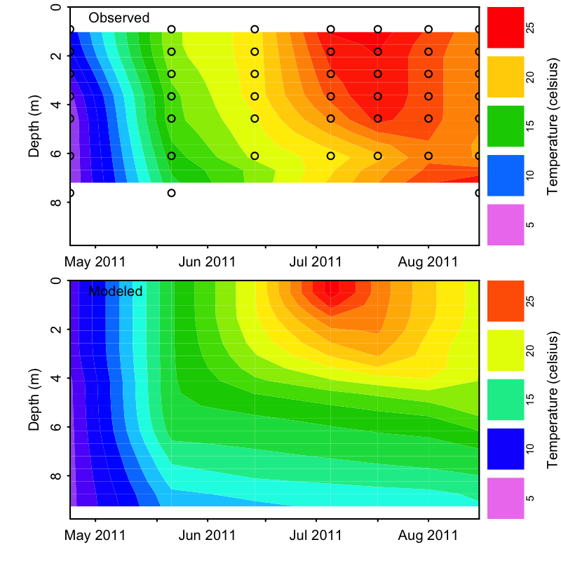

```r
field_file <- file.path(tmp_run_dir, "field_data.tsv")
plot_var_compare(nc_file, field_file, "temp", resample = TRUE,
    fig_path = "../images/temp_compare.png")
```